# StatR 502 Lecture 3: Logistic Regression

Gregor Thomas

Thursday, January 21, 2016

# Tonight’s Menu:

- Quick review
- Jumping right in to Logistic Regression!
  - Motivation
  - Quick example
  - Some diagnostics
  - More examples
  - Final thoughts

# Quick Review

Things you should know off the top of your head

- The beta hat waltz!
- The z-score for a 95% normal confidence interval
- AIC: which direction is better?
- What assumption is key for a Likelihood Ratio Test?
- The *most* important assumption for linear regression
- The *least* important assumption for linear regression
- What is the point of linear transformations of data?
- What is the difference between `dplyr::mutate` and `dplyr::summarize`?

# Quick Review

Things you should know off the top of your head

- The beta hat waltz! $\hat{\beta} = (X'X)^{-1}X' y$
- The z-score for 95% normal confidence interval: **1.96** (in R: `qnorm(0.975)`)
- AIC: which direction is better? Lower is better.
- What assumption is key for a Likelihood Ratio Test? - The models must be *nested*.
- The most important assumption regression assumption:
  - *validity,* your data should map to the question you’re trying to answer.
- The least important regression assumption:
  - *normality of errors*
  - **Not an assumption:** normality of data
- What is the point of linear transformations of data: *make interpretation easier*
- What is the difference between `dplyr::mutate` and `dplyr::summarize`?
  - `mutate` adds columns to the existing data, `summarize` collapses rows down to the group level and adds group summary columns.

# Generalized Linear Models

Logistic is the most common kind of GLM, we’ll talk about others next week.

Linear model:

$E(y) = X\beta$

Generalized Linear Model:

$g(E(y)) = X\beta \\ E(y) = g^{-1} (X \beta )$

The function $g$ is called the “link function”, and $X\beta$ is called the “linear predictor.”

A linear model is a special case of a GLM when $g$ is the identity function ($g(y) = y$).

# Our first GLM is an LM

```r
mt.lm = lm(mpg ~ wt, data = mtcars)
mt.glm = glm(mpg ~ wt, data = mtcars, family = gaussian(link = "identity"))

all.equal(coef(mt.lm), coef(mt.glm))
```

```
## [1] TRUE
```

The key difference is the `family` argument, which describes the error distribution and specifies a link function.

```r
summary(mt.lm)
```

```
##
## Call:
## lm(formula = mpg ~ wt, data = mtcars)
##
## Residuals:
##     Min      1Q  Median      3Q     Max
## -4.5432 -2.3647 -0.1252  1.4096  6.8727
##
## Coefficients:
##             Estimate Std. Error t value Pr(>|t|)
## (Intercept)  37.2851     1.8776  19.858  < 2e-16 ***
## wt           -5.3445     0.5591  -9.559 1.29e-10 ***
## ---
## Signif. codes:  0 '***' 0.001 '**' 0.01 '*' 0.05 '.' 0.1 ' ' 1
##
## Residual standard error: 3.046 on 30 degrees of freedom
## Multiple R-squared:  0.7528, Adjusted R-squared:  0.7446
## F-statistic: 91.38 on 1 and 30 DF,  p-value: 1.294e-10
```

```r
summary(mt.glm)
```

```
##
## Call:
## glm(formula = mpg ~ wt, family = gaussian(link = "identity"),
##     data = mtcars)
##
## Deviance Residuals:
##     Min       1Q   Median       3Q      Max
## -4.5432  -2.3647  -0.1252   1.4096   6.8727
##
## Coefficients:
##             Estimate Std. Error t value Pr(>|t|)
## (Intercept)  37.2851     1.8776  19.858  < 2e-16 ***
## wt           -5.3445     0.5591  -9.559 1.29e-10 ***
## ---
## Signif. codes:  0 '***' 0.001 '**' 0.01 '*' 0.05 '.' 0.1 ' ' 1
##
## (Dispersion parameter for gaussian family taken to be 9.277398)
##
##     Null deviance: 1126.05  on 31  degrees of freedom
## Residual deviance:  278.32  on 30  degrees of freedom
## AIC: 166.03
##
## Number of Fisher Scoring iterations: 2
```

In this case, the only difference is how the results are presented.

# Logistic regression

Every GLM has a (*exponential family*) distribution, and a link function.

When our outcome is binary we use the binomial distribution, which most commonly uses the logit function as link:

$\mathrm{logit}(p) = \log\Big(\frac{p}{1-p}\Big)$

The inverse logit function (which is rightly the logistic function, but also sometimes called the “expit” function is)

$\mathrm{expit}(x) = \frac{\exp(x)}{\exp(x) + 1}$

# Some quick plotting

```r
logit.plot = ggplot(data.frame(p = c(0.01, .99)), aes(p)) +
    stat_function(fun = logit) +
    labs(title = "Logit",
         y = expression(paste("X", beta, " (log odds-ratio)")),
         x = "Probability") +
    coord_equal(xlim = c(-0.5, 1.5)) +
    scale_x_continuous(breaks = c(0, 1))
invlogit.plot = ggplot(data.frame(xbeta = c(-5, 5)), aes(xbeta)) +
    stat_function(fun = invlogit) +
    labs(title = "Inverse Logit\n(or Logistic or Expit)",
         x = expression(paste("X", beta, " (log odds-ratio)")),
         y = "Probability") +
    coord_equal(ylim = c(-.5, 1.5)) +
    scale_y_continuous(breaks = c(0, 1))
```

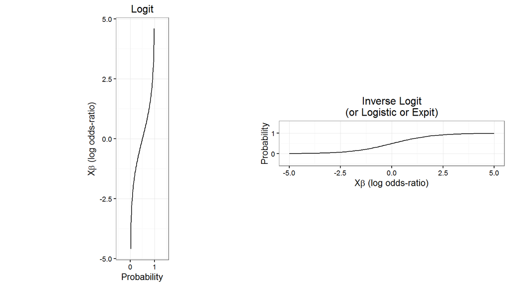

```r
library(gridExtra)
grid.arrange(logit.plot, invlogit.plot, nrow = 1)
```

# Let’s do logistic regression!

We’re going to start off with a mostly categorical data set, then we’ll look at G&H’s arsenic data to get practice with continuous variables.

```r
obese = read.csv("obese11.csv")
```

The first thing we should do is get a sense of the data.

```r
# the base r way
# counts by demography
table(obese$obese, obese$demog)
```

```
##
##     1White 2Black 3Latino 4NatAm 5Asian OthUknwn
##   0   5218   2084    3596    209    404      816
##   1    684    433     637     47     36      121
```

```r
table(obese$obese, obese$demog) %>%
    prop.table(margin = 2) %>%
    round(2)
```

```
##
##     1White 2Black 3Latino 4NatAm 5Asian OthUknwn
##   0   0.88   0.83    0.85   0.82   0.92     0.87
##   1   0.12   0.17    0.15   0.18   0.08     0.13
```

```r
# with dplyr
obese %>%
    group_by(demog) %>%
    mutate(demog.n = n()) %>%
    group_by(demog, obese) %>%
    summarize(n = n(), prop = round(n / first(demog.n), 2))
```

```
## Source: local data frame [12 x 4]
## Groups: demog [?]
##
##       demog obese     n  prop
##      (fctr) (int) (int) (dbl)
## 1    1White     0  5218  0.88
## 2    1White     1   684  0.12
## 3    2Black     0  2084  0.83
## 4    2Black     1   433  0.17
## 5   3Latino     0  3596  0.85
## 6   3Latino     1   637  0.15
## 7    4NatAm     0   209  0.82
## 8    4NatAm     1    47  0.18
## 9    5Asian     0   404  0.92
## 10   5Asian     1    36  0.08
## 11 OthUknwn     0   816  0.87
## 12 OthUknwn     1   121  0.13
```

```r
table(obese$obese, obese$female) %>%
    prop.table(margin = 2) %>%
    round(2)
```

```
##
##        0    1
##   0 0.83 0.90
##   1 0.17 0.10
```

### What do you think about the data coding?

- Why is demography coded this way?
- What’s nice about the way sex is coded?
  - Reference levels should usually be the biggest group
- Check-in about factors and modeling: should we convert `female` to a factor? How many coefficients will we get by using `demog`?

# Model time

Let’s fit a couple simple models:

```r
mod.f = glm(obese ~ female, data = obese, family = binomial(link = "logit"))
mod.fd = glm(obese ~ female + demog, data = obese, family = binomial)
display(mod.f)
```

```
## glm(formula = obese ~ female, family = binomial(link = "logit"),
##     data = obese)
##             coef.est coef.se
## (Intercept) -1.57     0.03
## female      -0.61     0.05
## ---
##   n = 14285, k = 2
##   residual deviance = 11266.2, null deviance = 11416.7 (difference = 150.5)
```

```r
display(mod.fd)
```

```
## glm(formula = obese ~ female + demog, family = binomial, data = obese)
##               coef.est coef.se
## (Intercept)   -1.76     0.04
## female        -0.62     0.05
## demog2Black    0.48     0.07
## demog3Latino   0.31     0.06
## demog4NatAm    0.54     0.17
## demog5Asian   -0.40     0.18
## demogOthUknwn  0.13     0.11
## ---
##   n = 14285, k = 7
##   residual deviance = 11189.2, null deviance = 11416.7 (difference = 227.5)
```

# Deviance

The new output includes *deviance*, both null and residual.

Deviance is defined as

$\mathrm{Deviance} = -2\log(L)$

So it ties right in with AIC and the LRT test statistic. *Null deviance* is the deviance of a model with only a single intercept term. The *residual deviance* is the deviance of the current model.

# Null deviance

```r
mod.null = glm(obese ~ 1, data = obese, family = binomial)
display(mod.null)
```

```
## glm(formula = obese ~ 1, family = binomial, data = obese)
##             coef.est coef.se
## (Intercept) -1.84     0.02
## ---
##   n = 14285, k = 1
##   residual deviance = 11416.7, null deviance = 11416.7 (difference = 0.0)
```

The null deviance is the deviance of the model fit with one parameter (the intercept). It gives a useful baseline.

What probability does the intercept correspond to?

The intercept gives the overall probability of the response. We can get there a few ways:

```r
# by default, predict will give the *linear predictor* value
predict(mod.null, newdata = data.frame(x = 1))
```

```
##         1
## -1.839868
```

```r
# with GLMs, usually we want the *response*, with the link function applied
predict(mod.null, newdata = data.frame(x = 1), type = "response", se.fit = T)
```

```
## $fit
##         1
## 0.1370669
##
## $se.fit
##           1
## 0.002877494
##
## $residual.scale
## [1] 1
```

```r
invlogit(coef(mod.null)) # directly from the model coef
```

```
## (Intercept)
##   0.1370669
```

```r
mean(obese$obese)        # directly from the data
```

```
## [1] 0.1370669
```

# Exploratory Interlude

Take a look glance at the codebook (posted online), download the data (if you haven’t already), and fit some logistic models.

# A little model comparison

Of course we should look at the AIC

```r
AIC(mod.null, mod.f, mod.fd)
```

```
##          df      AIC
## mod.null  1 11418.66
## mod.f     2 11270.19
## mod.fd    7 11203.20
```

```r
BIC(mod.null, mod.f, mod.fd)
```

```
##          df      BIC
## mod.null  1 11426.23
## mod.f     2 11285.32
## mod.fd    7 11256.17
```

# Likelihood ratio tests

The LRT test statistic is the difference in deviances.

$\begin{aligned} \mathrm{LRT \, statistic} &= -2\log \Big(\frac{L_{null}}{L_{alt}}\Big) \\ &= -2 \log \Big(L_{null}\Big) - (-2) \log \Big(L_{alt}\Big) \\ &= \mathrm{deviance}(\mathrm{null}) - \mathrm{deviance}(\mathrm{alt}) \end{aligned}$

The LRT statistic has a chi-squared distribution, with degrees of freedom of the *difference* of the degrees of freedom of the two models. The LRT test statistic is only valid for nested models.

```r
library(lmtest)
lrtest(mod.f, mod.fd)
```

```
## Likelihood ratio test
##
## Model 1: obese ~ female
## Model 2: obese ~ female + demog
##   #Df  LogLik Df  Chisq Pr(>Chisq)
## 1   2 -5633.1
## 2   7 -5594.6  5 76.983  3.587e-15 ***
## ---
## Signif. codes:  0 '***' 0.001 '**' 0.01 '*' 0.05 '.' 0.1 ' ' 1
```

# Interpreting logistic regression coefficients

The linear predictor corresponds to the *log-odds*, so a single coefficient estimate is the *change in the log-odds* per *unit change in the predictor*… pretty terrible to explain.

Exponentiating the predictors gets us **multipliers** of the odds ratio (why multiplicative, not additive?), which is better.

```r
coef(mod.f)
```

```
## (Intercept)      female
##  -1.5693627  -0.6054201
```

- The log odds that a female subject in this data is obese is -.6 less than the log odds that a male subject is obese.
- The odds that a female subject in this data is obese are `exp(-0.6)` = 0.5488 times the odds that a male subject is obese.

(Taking no other variables into account.)

### What does multiplying the log-odds do to the probability?

Depends on where you start, that’s what makes things hard.

- At the tails (when $p$ is close to 0 or 1), multiplying the odds-ratio is approximately equal to multiplying the (smaller) probability.
  - At $p = 0.01$, doubling the odds-ratio is very close to doubling the probability.  
    Closer to the middle the changes aren’t as extreme
  - At $p = 0.5$, (odds-ratio = 1), doubling the odd-ratio (it goes 2) corresponds to a probability of $p = 0.6667$.

# We could write functions…

See if you can define two functions, `prob_to_or()` and `or_to_prob()`. (Use `logit()` and `arm::invlogit()` as needed.)

Remember

- $\mathrm{logit}(p) = \log\Big(\frac{p}{1-p}\Big)$
- $\mathrm{expit}(x) = \frac{\exp(x)}{\exp(x) + 1}$
- $\mathrm{OR} = \frac{p}{1-p}$

# One way to do it:

```r
prob_to_or = function(p) {
    return(p / (1 - p))
}

or_to_prob = function(or) {
    return(invlogit(log(or)))
}

p = 0.01
p %>% prob_to_or %>% prod(2) %>% or_to_prob
```

```
## [1] 0.01980198
```

```r
p = 0.5
p %>% prob_to_or %>% prod(2) %>% or_to_prob
```

```
## [1] 0.6666667
```

# Adding to our plot duo

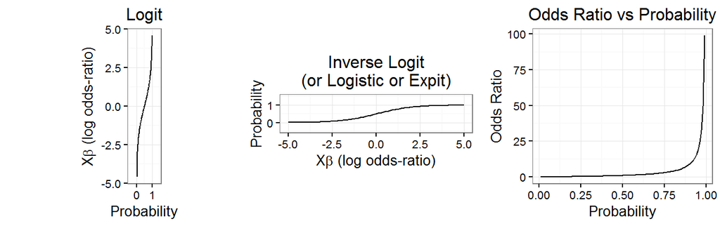

```r
or.plot = ggplot(data.frame(p = c(0.01, .99)), aes(p)) +
stat_function(fun = prob_to_or) +
labs(title = "Odds Ratio vs Probability",
x = "Probability",
y = "Odds Ratio")

grid.arrange(logit.plot, invlogit.plot, or.plot, nrow = 1)
```

# Visualizing model results

First let’s sweep up the data:

```r
fd.coef = tidy(mod.fd)
fd.coef = mutate(
    fd.coef,
    term = factor(term),
    term = reorder(term, X = estimate),
    exp.estimate = exp(estimate),
    exp.se = exp(std.error)
)
```

# Visualizing model results

Log-odds, the scale is hard to read interpret!

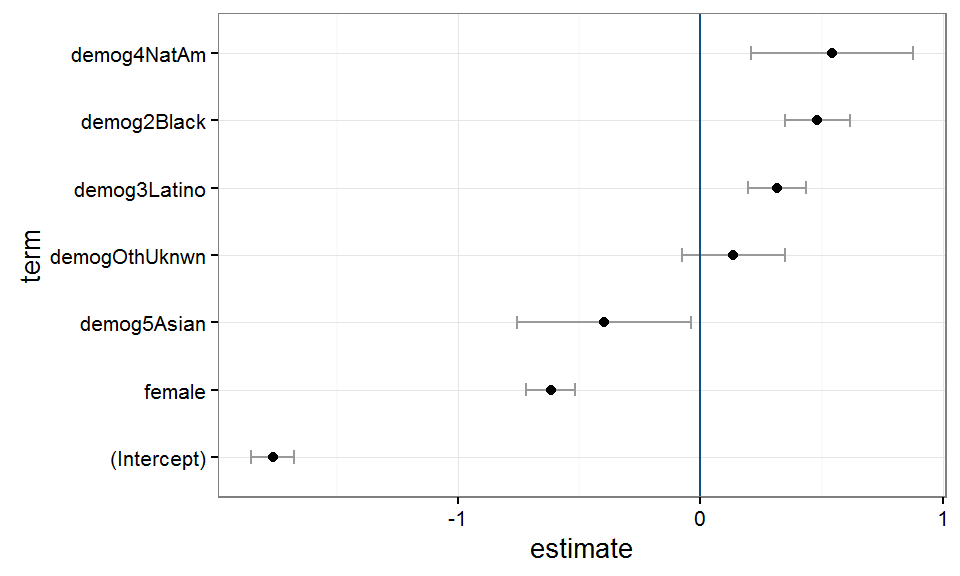

```r
fd.logodds = ggplot(fd.coef, aes(x = estimate, y = term)) +
    geom_errorbarh(aes(xmin = estimate - 2 * std.error,
                       xmax = estimate + 2 * std.error),
                   height = 0.2, color = "gray60") +
    geom_point() +
    geom_vline(xintercept = 0, color = "dodgerblue4")
fd.logodds
```

# Visualizing model results

Same as before but using exponentiated coefficients (odds ratios). I find the x-scale here misleading, because multiplying by 0.5 is equal and opposite to multiplying by 2…

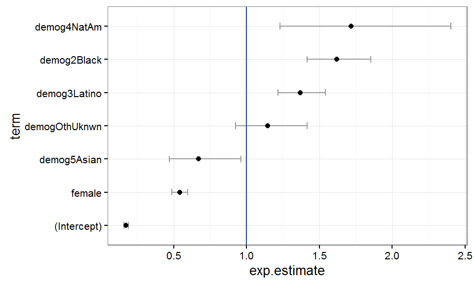

```r
fd.or = ggplot(fd.coef, aes(x = exp.estimate, y = term)) +
    geom_errorbarh(aes(xmin = exp.estimate / exp.se^2,
                       xmax = exp.estimate * exp.se^2),
                   height = 0.2, color = "gray60") +
    geom_point() +
    geom_vline(xintercept = 1, color = "dodgerblue4")
fd.or
```

The OR, plotted on a log scale, is the best of both worlds: readable, interpretable labels *and* distance meaning the same thing on either side of 1.

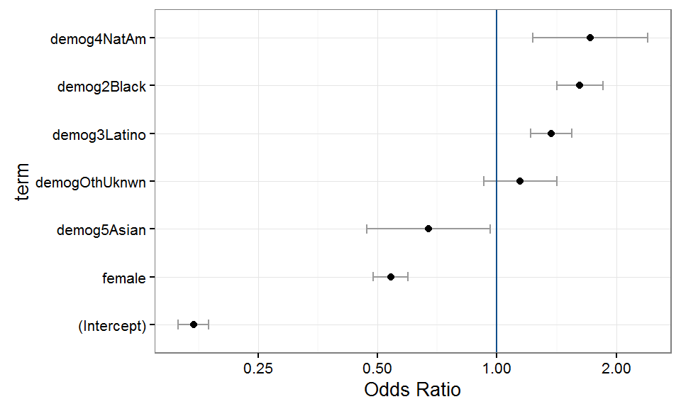

```r
fd.or + scale_x_continuous(trans = "log", breaks = c(0.25, 0.5, 1, 2)) +
    labs(x = "Odds Ratio")
```

# Getting back to probabilities

As far as getting the actual probabilities, G&H rely a lot on `coef()` and matrix multiplication. I prefer to let `predict()` do the heavy lifting:

```r
# create some data
pr.dat = expand.grid(unique(obese$female), levels(obese$demog))
names(pr.dat) = c("female", "demog")
head(pr.dat)
```

```
##   female   demog
## 1      1  1White
## 2      0  1White
## 3      1  2Black
## 4      0  2Black
## 5      1 3Latino
## 6      0 3Latino
```

```r
pr.dat$phat = predict(mod.fd, newdata = pr.dat, type = "response") %>%
    round(3)
pr.dat
```

```
##    female    demog  phat
## 1       1   1White 0.085
## 2       0   1White 0.146
## 3       1   2Black 0.130
## 4       0   2Black 0.217
## 5       1  3Latino 0.112
## 6       0  3Latino 0.190
## 7       1   4NatAm 0.137
## 8       0   4NatAm 0.227
## 9       1   5Asian 0.058
## 10      0   5Asian 0.103
## 11      1 OthUknwn 0.096
## 12      0 OthUknwn 0.164
```

# Questions?

- In lab, we’ll take a look at continuous predictors with GLM (using the well-switching data from G&H), and explore more plotting options.
- Considerations for transforming predictors are just about the same for GLMs as for LMs.

# Other input options

`glm` is nicely flexible when it comes to data formats for logistic regression. The most common is the format of the YRBS data: the response is one vector of 0’s and 1’s. You can also give two-column matrix as the response, the first column a count of successes, the second a count failures.

A third option is to give a proportion of successes as the response and use the `weights` argument to specify the number of attempts, but this seems less stable.

# How are GLM’s calculated?

You’ve maybe noticed there’s been no new version of the “beta-hat waltz” for logistic regression. In fact, there’s no closed-form solution to find the MLE. The solution is found numerically, searching the likelihood function for it’s maximum. The usual method is:

1. Calculate the log-likelihood’s gradient w.r.t. the $\beta$’s, known among statisticians as **the score;**
2. Using Iteratively Reweighted Least Squares (IRLS or IWLS), numerically push the score towards zero (a.k.a. **solving the score equations**). Once you’re close enough, you’ve found your $\hat{\beta}$’s.
3. Take the second derivative of log-likelihood at $\beta=\hat{\beta}$, to calculate the SEs of $\hat{\beta}$.
4. If the distribution has a scale/noise parameter $\phi$ (known in GLM as **the dispersion parameter**), you estimate it empirically “on the side” after finding $\hat{\beta}$ (just like we estimate $\hat{\sigma}^2$ in linear regression).